# R Assignment 3

Keeno Glanville

2022-07-28

# What factor influences crime?

### Load data(bonus)

```r
set.seed(1324)
urldata <- "https://raw.githubusercontent.com/vincentarelbundock/Rdatasets/master/csv/AER/Guns.csv"
gundata.r <- read_csv(url(urldata))
```

```
## * `` -> ...1
```

## We first start by cleaning the data set and renaming columns to make the names clearer

```r
gundata_clean <- gundata.r %>%
  select(-"...1", -"male")%>%
  rename("%Black" = "afam",
         "%White"= "cauc",
         "Crime/100k" = "violent",
         "Murder/100k" = "murder",
         "Robbery/100k" = "robbery",
         "Prisoners/100k" = "prisoners",
         "Income/capitaofstate" = "income",
         "Density(sqrmi/1000)" = "density",
          ShallCarryLaw = "law",
         "population/mil" = population)
view(gundata_clean)

summary(gundata_clean)
```

```
##       year        Crime/100k      Murder/100k      Robbery/100k
##  Min.   :1977   Min.   :  47.0   Min.   : 0.200   Min.   :   6.4
##  1st Qu.:1982   1st Qu.: 283.1   1st Qu.: 3.700   1st Qu.:  71.1
##  Median :1988   Median : 443.0   Median : 6.400   Median : 124.1
##  Mean   :1988   Mean   : 503.1   Mean   : 7.665   Mean   : 161.8
##  3rd Qu.:1994   3rd Qu.: 650.9   3rd Qu.: 9.800   3rd Qu.: 192.7
##  Max.   :1999   Max.   :2921.8   Max.   :80.600   Max.   :1635.1
##  Prisoners/100k       %Black            %White      population/mil
##  Min.   :  19.0   Min.   : 0.2482   Min.   :21.78   Min.   : 0.4027
##  1st Qu.: 114.0   1st Qu.: 2.2022   1st Qu.:59.94   1st Qu.: 1.1877
##  Median : 187.0   Median : 4.0262   Median :65.06   Median : 3.2713
##  Mean   : 226.6   Mean   : 5.3362   Mean   :62.95   Mean   : 4.8163
##  3rd Qu.: 291.0   3rd Qu.: 6.8507   3rd Qu.:69.20   3rd Qu.: 5.6856
##  Max.   :1913.0   Max.   :26.9796   Max.   :76.53   Max.   :33.1451
##  Income/capitaofstate Density(sqrmi/1000)    state           ShallCarryLaw
##  Min.   : 8555        Min.   : 0.000707   Length:1173        Length:1173
##  1st Qu.:11935        1st Qu.: 0.031911   Class :character   Class :character
##  Median :13402        Median : 0.081569   Mode  :character   Mode  :character
##  Mean   :13725        Mean   : 0.352038
##  3rd Qu.:15271        3rd Qu.: 0.177718
##  Max.   :23647        Max.   :11.102120
```

### We wil now pair the data together to recognize the trends within our data

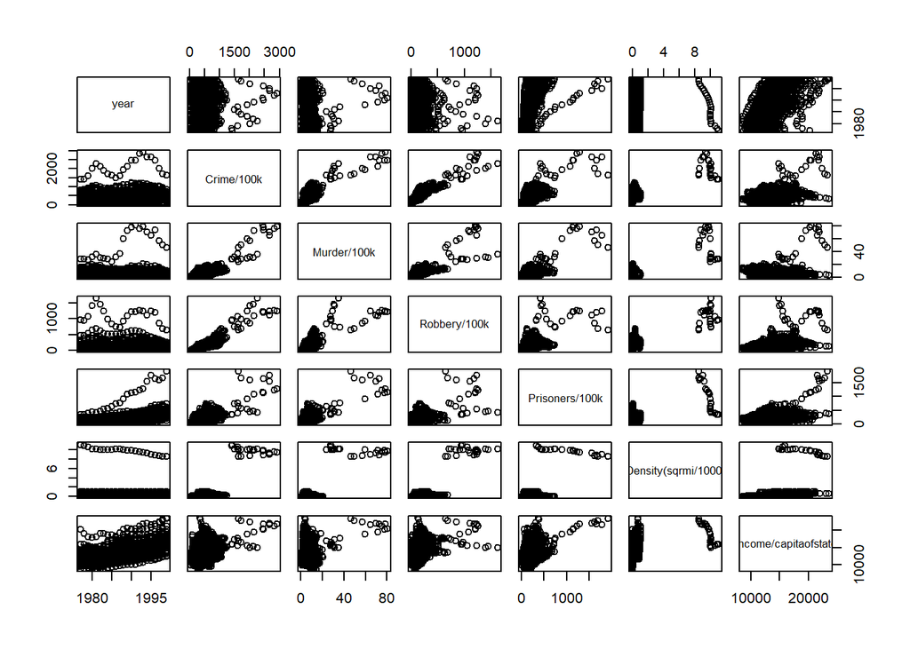

```r
gundata_pairs <- gundata_clean%>%
  mutate(ShallCarryLaw = ifelse(ShallCarryLaw == "no",0,1))
pairs(data=gundata_pairs,
      ~ year+ `Crime/100k`+ `Murder/100k` + `Robbery/100k`+ `Prisoners/100k`+
        `Density(sqrmi/1000)` + `Income/capitaofstate`)
```

## In the before step we see tremendous trends within the data and now we want to see our correlation coefficients

### We will print corrplot and histograms as well as boxplots

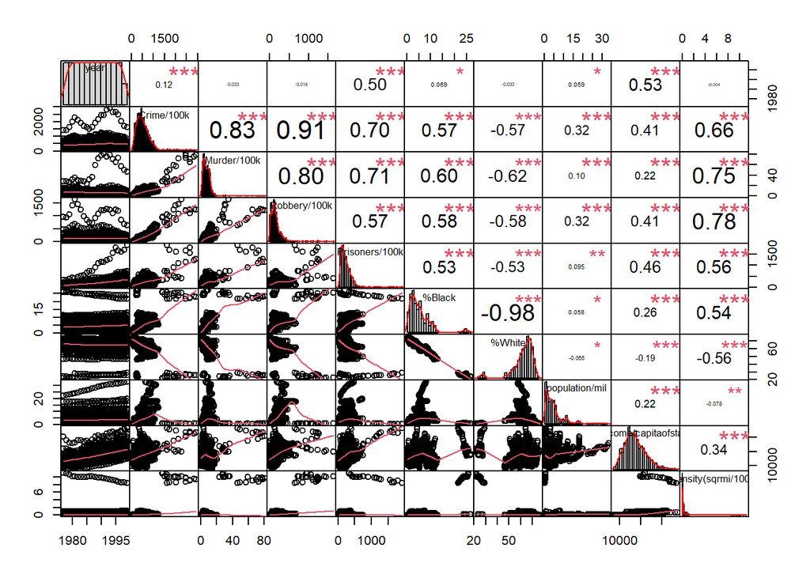

```r
gundata_corplot <- gundata_clean %>%
  select(-"state", -"ShallCarryLaw")

chart.Correlation(gundata_corplot,
                  method="pearson",
                  histogram=TRUE,
                  pch=16)
```

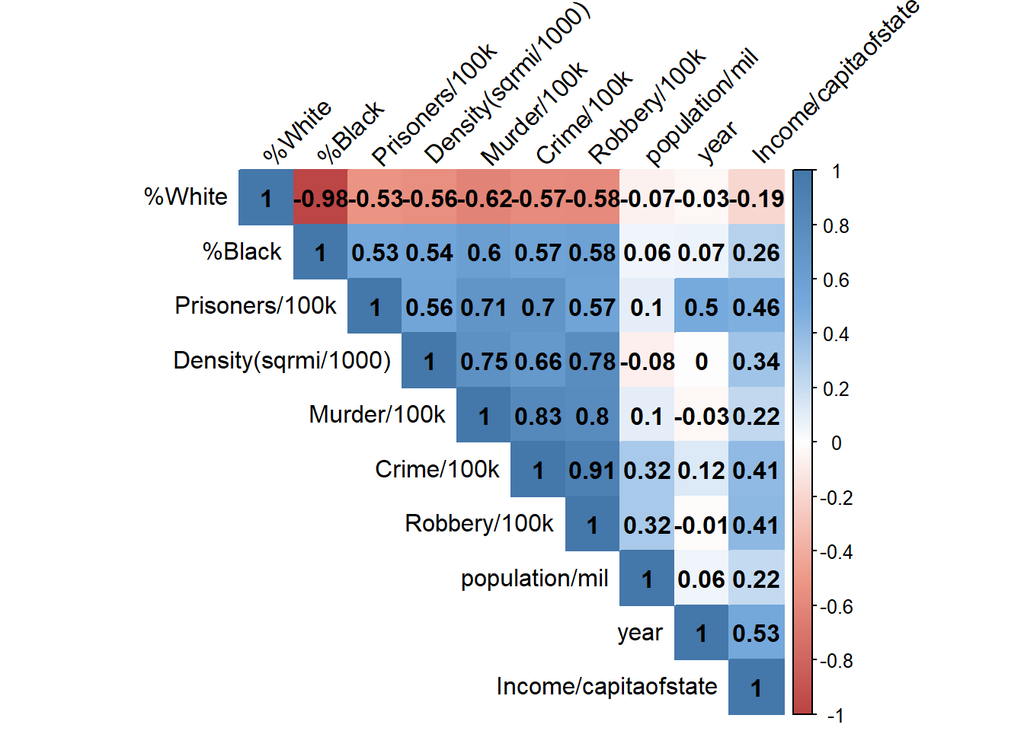

```r
gundata_cor <- cor(gundata_corplot, method = "pearson")
col_gd <- colorRampPalette(c("#BB4444", "#EE9988", "#FFFFFF", "#77AADD", "#4477AA"))
corrplot(gundata_cor, method = "color", col = col_gd(200),
         type = "upper", order = "hclust",
         addCoef.col = "black",
         tl.col = "black", tl.srt = 45,)
```

# BoxPlot shows the trend of crime over the years, with a slight trend upwards heavily skewed by District of Columbia

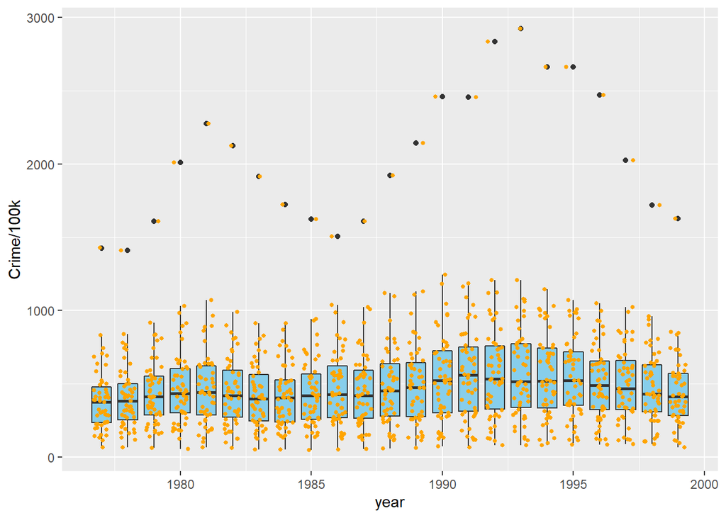

```r
ggplot(gundata_clean, aes(x= year, y= `Crime/100k`, group = `year`)) +
         geom_boxplot( fill="skyblue", notch=FALSE) +
         geom_jitter( size=1, color="orange", width=0.3)
```

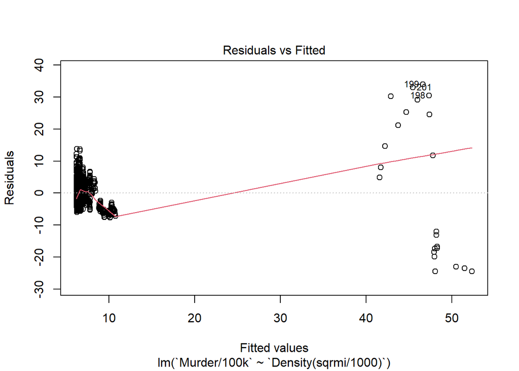

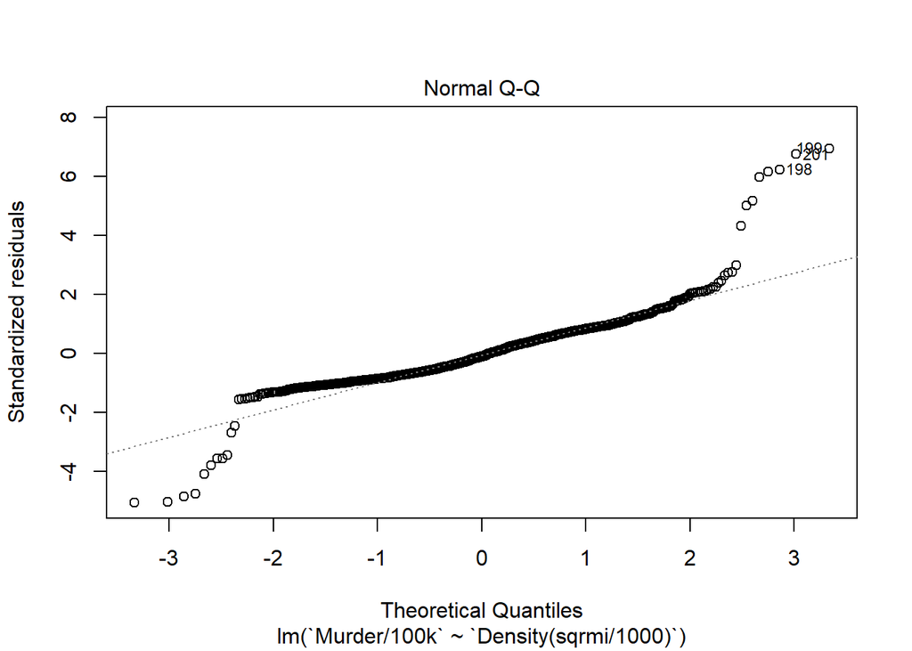

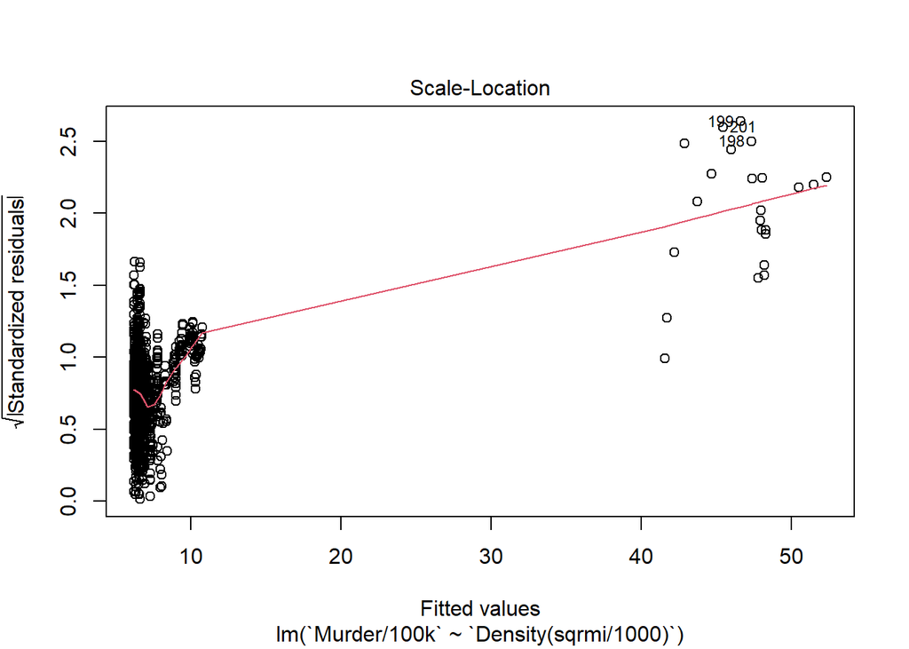

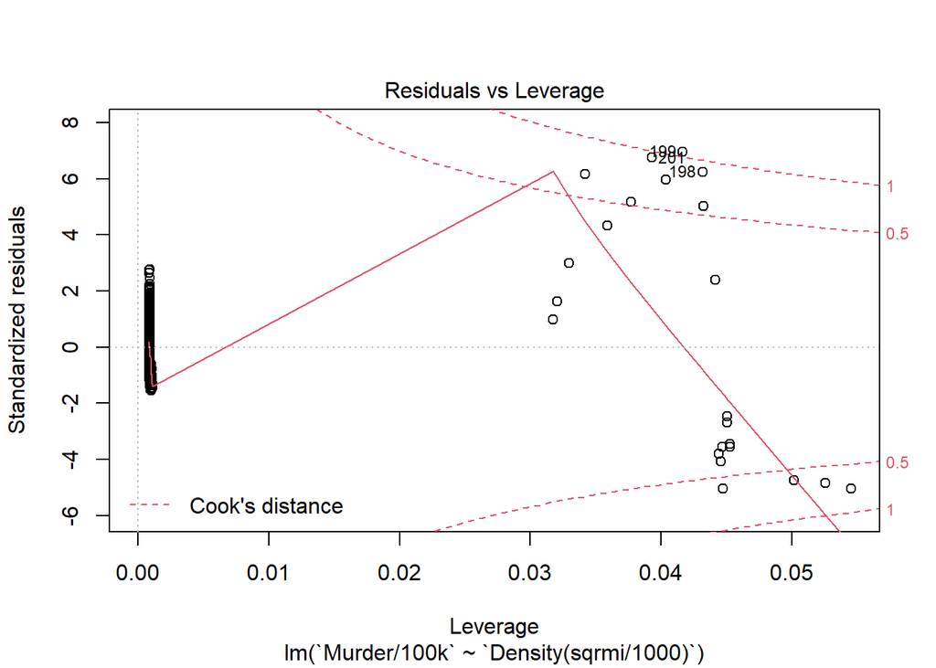

```r
attach(gundata_clean)
DensityvMurder <- lm(`Murder/100k` ~ `Density(sqrmi/1000)`, data = gundata_clean)
plot(DensityvMurder, ask =FALSE)
```

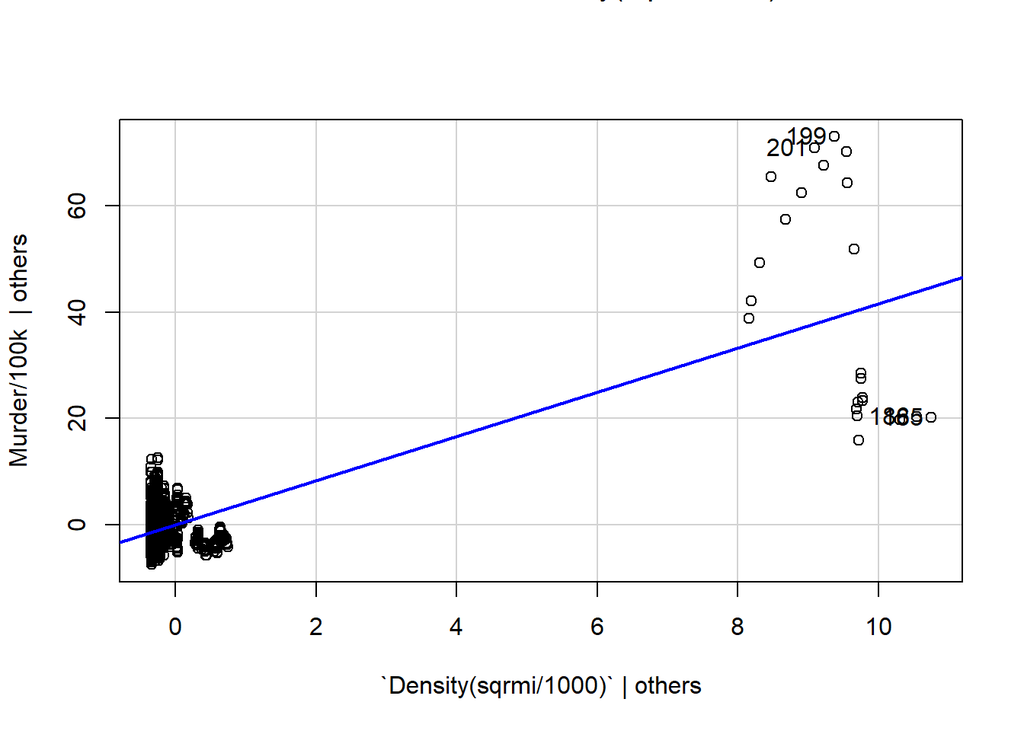

```r
avPlots(DensityvMurder)
```

```r
detach(gundata_clean)
```

## Now we want to look at plots of crime with regards to state. We see District of Columbia elevated overall

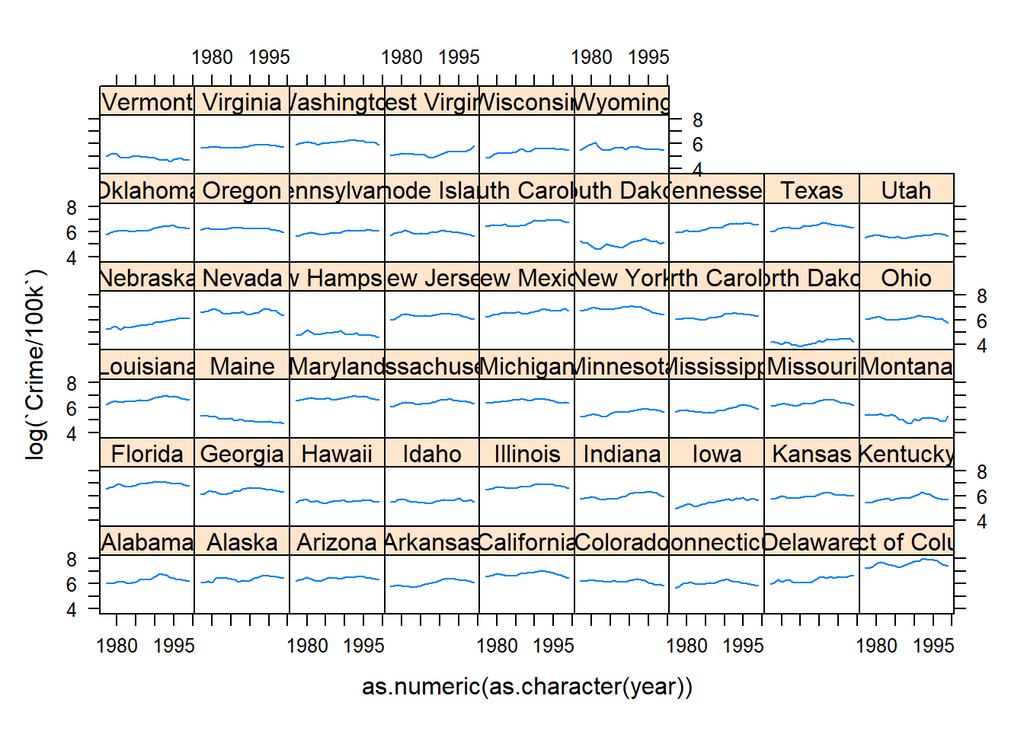

```r
xyplot(log(`Crime/100k`) ~ as.numeric(as.character(year)) | state, data = gundata_clean, type = "l")
```

# We conclude that we see the data is heavily skewed due to the District of Columbia

```r
summary(DensityvMurder)
```

```
##
## Call:
## lm(formula = `Murder/100k` ~ `Density(sqrmi/1000)`, data = gundata_clean)
##
## Residuals:
##     Min      1Q  Median      3Q     Max
## -24.548  -3.364  -0.501   2.897  33.993
##
## Coefficients:
##                       Estimate Std. Error t value Pr(>|t|)
## (Intercept)             6.2026     0.1505   41.20   <2e-16 ***
## `Density(sqrmi/1000)`   4.1546     0.1075   38.64   <2e-16 ***
## ---
## Signif. codes:  0 '***' 0.001 '**' 0.01 '*' 0.05 '.' 0.1 ' ' 1
##
## Residual standard error: 4.99 on 1171 degrees of freedom
## Multiple R-squared:  0.5604, Adjusted R-squared:   0.56
## F-statistic:  1493 on 1 and 1171 DF,  p-value: < 2.2e-16
```

# We want to compare the data again but removing District of Columbia as a huge outlier

### Plots redone without District of Columbia

```r
attach(gundata_clean)
gundata.noDOC <- filter(gundata_clean, state != "District of Columbia")
gundata_noDOC <- gundata.noDOC %>%
  select(-"state", -"ShallCarryLaw")
detach(gundata_clean)

summary(gundata.noDOC)
```

```
##       year        Crime/100k      Murder/100k      Robbery/100k
##  Min.   :1977   Min.   :  47.0   Min.   : 0.200   Min.   :  6.4
##  1st Qu.:1982   1st Qu.: 281.5   1st Qu.: 3.600   1st Qu.: 70.2
##  Median :1988   Median : 437.5   Median : 6.300   Median :122.4
##  Mean   :1988   Mean   : 472.2   Mean   : 6.833   Mean   :143.7
##  3rd Qu.:1994   3rd Qu.: 635.2   3rd Qu.: 9.600   3rd Qu.:188.5
##  Max.   :1999   Max.   :1244.3   Max.   :20.300   Max.   :684.0
##  Prisoners/100k      %Black            %White      population/mil
##  Min.   : 19.0   Min.   : 0.2482   Min.   :23.52   Min.   : 0.4027
##  1st Qu.:113.0   1st Qu.: 2.1603   1st Qu.:60.29   1st Qu.: 1.2424
##  Median :183.0   Median : 3.9651   Median :65.34   Median : 3.2889
##  Mean   :211.5   Mean   : 4.9652   Mean   :63.71   Mean   : 4.9006
##  3rd Qu.:285.0   3rd Qu.: 6.4426   3rd Qu.:69.29   3rd Qu.: 5.7378
##  Max.   :736.0   Max.   :26.9796   Max.   :76.53   Max.   :33.1451
##  Income/capitaofstate Density(sqrmi/1000)    state           ShallCarryLaw
##  Min.   : 8555        Min.   :0.0007071   Length:1150        Length:1150
##  1st Qu.:11897        1st Qu.:0.0315201   Class :character   Class :character
##  Median :13316        Median :0.0795802   Mode  :character   Mode  :character
##  Mean   :13623        Mean   :0.1636141
##  3rd Qu.:15162        3rd Qu.:0.1682232
##  Max.   :23647        Max.   :1.0976430
```

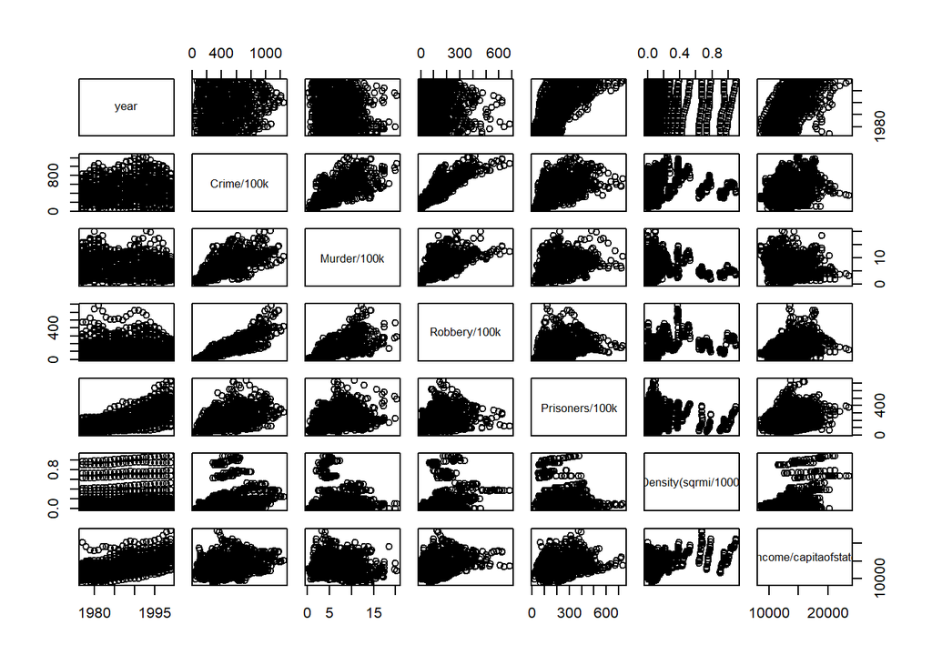

```r
pairs(data=gundata_noDOC,
      ~ year+ `Crime/100k`+ `Murder/100k` + `Robbery/100k`+ `Prisoners/100k`+
        `Density(sqrmi/1000)` + `Income/capitaofstate`)
```

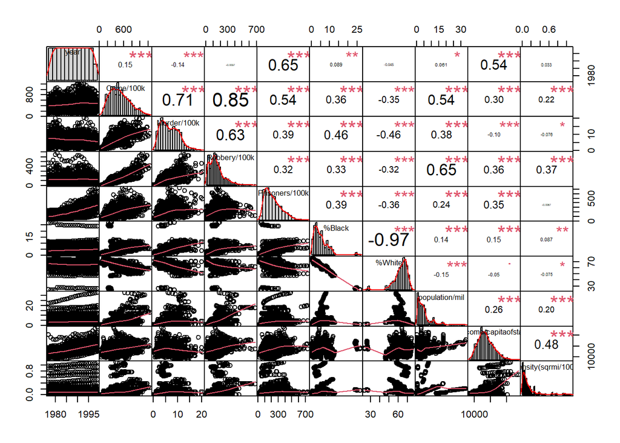

```r
chart.Correlation(gundata_noDOC,
                  method="pearson",
                  histogram=TRUE,
                  pch=16)
```

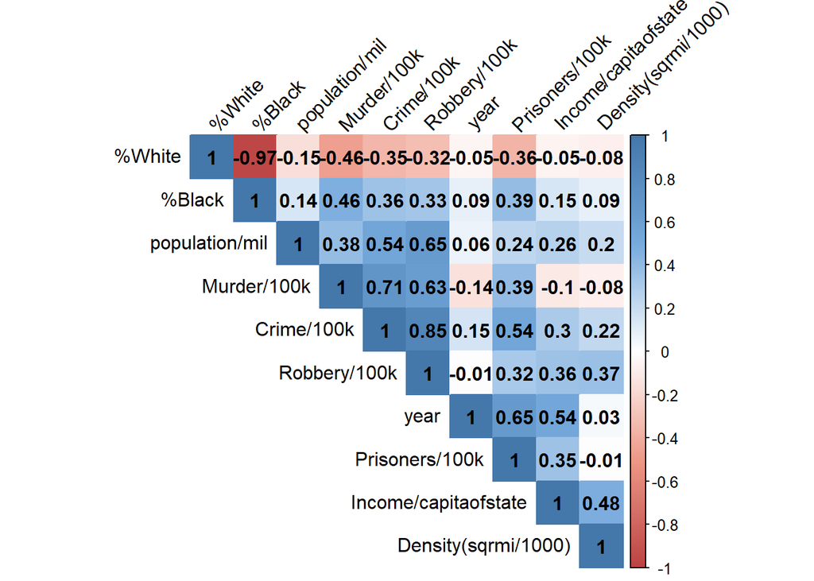

```r
gundata_noDOC_cor <- cor(gundata_noDOC,  method = "pearson")
col_noDOC <- colorRampPalette(c("#BB4444", "#EE9988", "#FFFFFF", "#77AADD", "#4477AA"))
corrplot(gundata_noDOC_cor, method = "color", col = col_noDOC(200),
         type = "upper", order = "hclust",
         addCoef.col = "black",
         tl.col = "black", tl.srt = 45,)
```

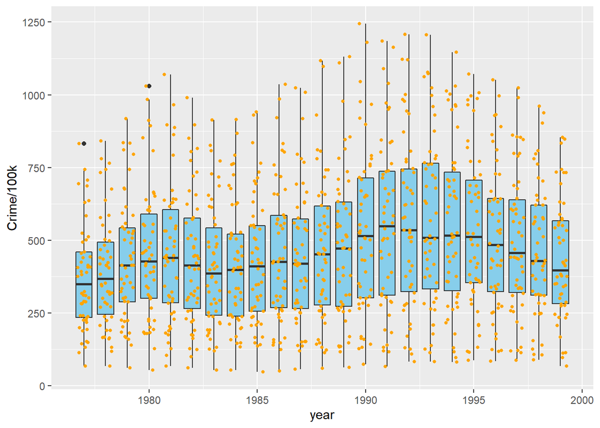

```r
ggplot(gundata_noDOC, aes(x= year, y= `Crime/100k`, group = `year`)) +
  geom_boxplot( fill="skyblue", notch=FALSE) +
  geom_jitter( size=1, color="orange", width=0.3)
```